# So, just how useless is the U.S. Congress?

Samantha Tyner  
25 Apr 2014

### Motivation

I chose this project because I, not unlike most Americans, am extremely frustrated with the U.S. Congress, and when I happened upon [this blog post](http://wonkviz.tumblr.com/post/74277939647/connecting-the-dots-between-partisanship-and-gridlock) that cited the [Vital Statistics on Congress](http://www.brookings.edu/research/reports/2013/07/vital-statistics-congress-mann-ornstein) from the Brookings Institute, I decided to investigate the history of congress as it relates to partisanship and congressional productivity. I also want to look at the field of candidates for this year's election, available from the [FEC](http://www.fec.gov/data/CandidateSummary.do) to see if there's any hope for improved productivity in 2015-2016.

See also: [Why Does Congress Suck?](http://youtu.be/V0CvmK0dVcI)

### Disclaimer

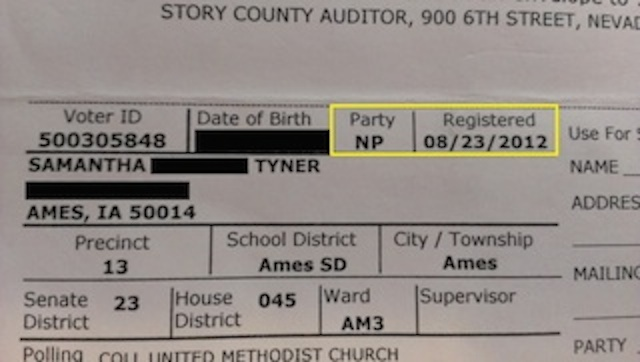

### Data

- [Brookings Data](http://www.brookings.edu/%7E/media/Research/Files/Reports/2013/07/vital%20statistics%20congress%20mann%20ornstein/Vital%20Statistics%20Full%20Data%20Set.pdf): Either PDF (yikes!) or Excel format.
  - Excel: better, but 10+ sheets per file
  - Use the XLConnect package to read in the data

```r
library(XLConnect)
wb <- loadWorkbook("~/.../...Demographics of Members of Congress.xlsx")
seniority = readWorksheet(wb, sheet = "1-6",startRow=4,endRow=127)
```

```
     Congress X1.term X2.terms X3.terms X1...3.terms X4...6.terms
1 83rd (1953)      NA       NA       NA           NA           NA
2     Percent   18.71    16.86    14.78        50.35        27.02
3       Seats   81.00    73.00    64.00       218.00       117.00
4        <NA>      NA       NA       NA           NA           NA
5 84th (1955)      NA       NA       NA           NA           NA
6     Percent   13.10    16.78    14.48        44.37        27.36
  X7...9.terms X10...terms Total Mean.term Median.term
1           NA          NA  <NA>        NA          NA
2        13.39       9.238  <NA>       4.5           3
3        58.00      40.000  433a        NA          NA
4           NA          NA  <NA>        NA          NA
5           NA          NA  <NA>        NA          NA
6        16.78      11.494  <NA>       5.0           4
```

### Data, cont.

The Brookings data have almost all of the most common problems with messy data that are listed in Wickham's “Tidy Data” paper, sometimes two or more in one data table

- column headers are values, not variable names
- multiple variables are stored in one column
- variables are stored in both rows and columns
- multiple types of observational units are stored in the same table
- a single observational unit is stored in multiple tables

Because of the inherent messiness of the data, the bulk of the work I did on this project involved cleaning the data and formatting it for visualization.

### Data, cont.

- [FEC](http://www.fec.gov/data/CandidateSummary.do)
  - Tried using XML, but doesn't work because the website is mostly Javascript, and it queries a database every time it is loaded, so there is no HTML to be read
  - Downloaded a CSV file instead (kind of a cop-out)
  - Fairly straightforward compared to the Brookings data

### Data, cont.

FEC data:

```
                      Name Office State
1             AALDERS, TIM      H    UT
2 ABBOTT, RICHARD ALLEN IV      H    MI
3          ABELER, JAMES J      S    MN
4                  ABRAHAM      H    UT
5          ABRAHAMS, KEVAN      H    NY
```

```
  District Party     Status
1        4   IAP       OPEN
2        3   DEM CHALLENGER
3        0   REP CHALLENGER
4        3   IAP CHALLENGER
5        4   DEM       OPEN
```

### Data Cleaning

In addition to XLConnect, I also relied heavily on:

- reshape, reshape2
- plyr
- dplyr

### Messy Data Example

Defeated House Incumbents, 1946-2012

```
  Election      Party Incumbents.lost X1
1     1946   Democrat              62 35
2     <NA> Republican               7  2
3     <NA>      Total              69 37
4     <NA>       <NA>              NA NA
```

```
  X2 X3 X1...3 X4...6 X7...9 X10.
1  5  4     44     11      5    2
2  0  1      3      3      1    0
3  5  5     47     14      6    2
4 NA NA     NA     NA     NA   NA
```

(an example of columns headers being values instead of variables)

### After some cleaning...

```
    Year      Party Terms In.lost Avg.terms
1   1946   Democrat     1      35       2.7
2   1946 Republican     1       2       3.6
47  1946   Democrat     2       5       2.7
48  1946 Republican     2       0       3.6
93  1946   Democrat     3       4       2.7
94  1946 Republican     3       1       3.6
139 1946   Democrat   4-6      11       2.7
140 1946 Republican   4-6       3       3.6
185 1946   Democrat   7-9       5       2.7
186 1946 Republican   7-9       1       3.6
231 1946   Democrat   10+       2       2.7
232 1946 Republican   10+       0       3.6
3   1948   Democrat     1       4       2.7
4   1948 Republican     1      41       2.2
49  1948   Democrat     2       1       2.7
```

### More Messy Data

Democratic and Republican Seats in the Senate by Region

```
   Region     D     R Col4   D.1 R.1
1   South    NA    NA   NA    NA  NA
2 Percent 53.66 0.000   NA 28.95   0
3   Seats 22.00 0.000   NA 22.00   0
4    <NA>    NA    NA   NA    NA  NA
5  Border    NA    NA   NA    NA  NA
6 Percent 12.20 9.259   NA 13.16   0
7   Seats  5.00 5.000   NA 10.00   0
```

Column headers are values (D or R), and multiple variables are stored in one column (region, percent, and seat count in one column). Has the additional problem of congress and year (two more variables) stored on top of the two D and R columns, as well as a lot of empty columns and rows. Silly Excel.

### Cleaned Data

```
  Congress        Region Office
1       69        Border  House
2       69  Mid-Atlantic  House
3       69       Midwest  House
4       69   New England  House
5       69 Pacific Coast  House
6       69        Plains  House
```

```
     Party Count
1 Democrat    27
2 Democrat    24
3 Democrat    14
4 Democrat     4
5 Democrat     4
6 Democrat     6
```

### Congressional Demographics

First, I look at how congress has changed over time.

- House seats per state after census
- Strength of the democratic party by state
- Diversity of congresspeople

### House Representatives per State

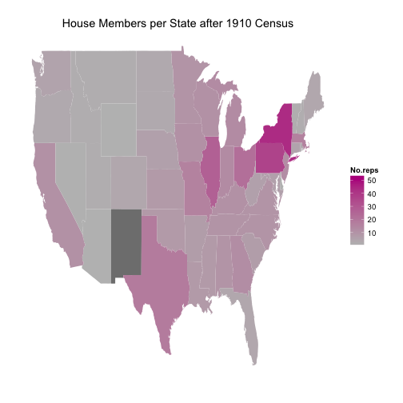

### House Representatives per State

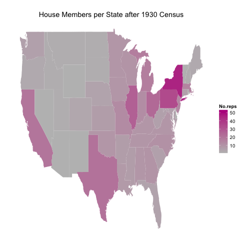

### House Representatives per State

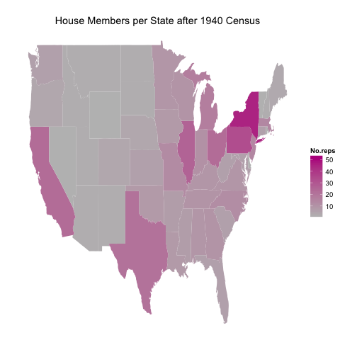

### House Representatives per State

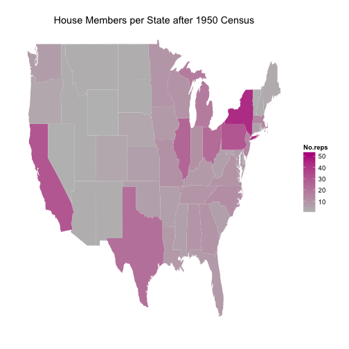

### House Representatives per State

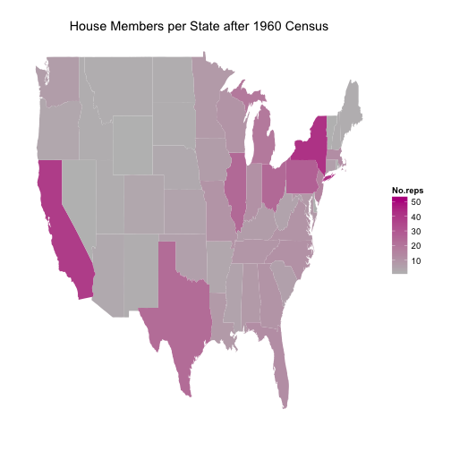

### House Representatives per State

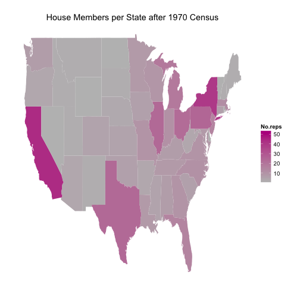

### House Representatives per State

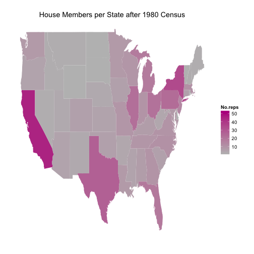

### House Representatives per State

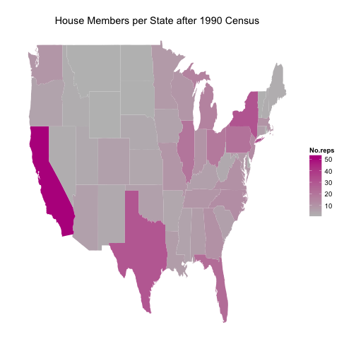

### House Representatives per State

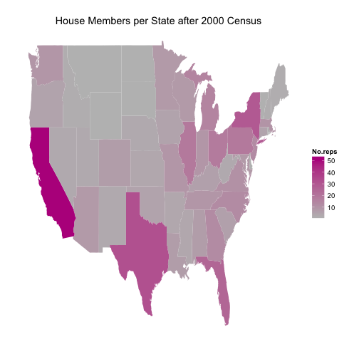

### House Representatives per State

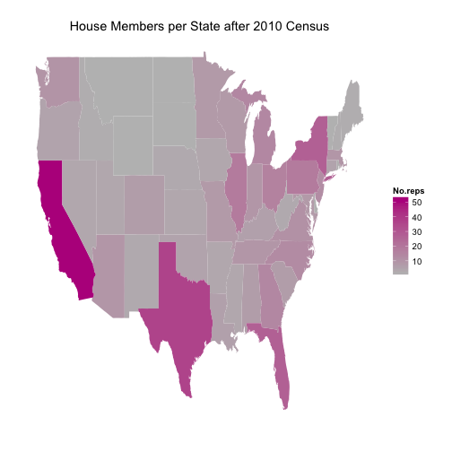

### House Representatives per State

- Representatives spread west as time goes on.
- Concentrate into California, Texas, Flordia, and away from New York and New England.

### Regional Democratic Strength

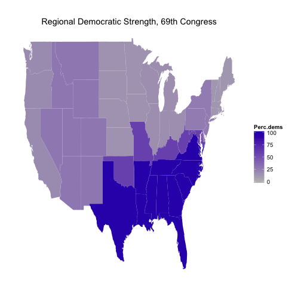

### Regional Democratic Strength

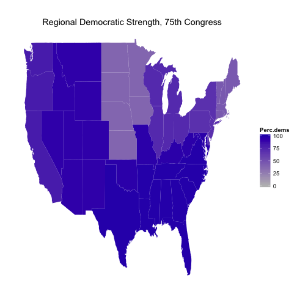

### Regional Democratic Strength

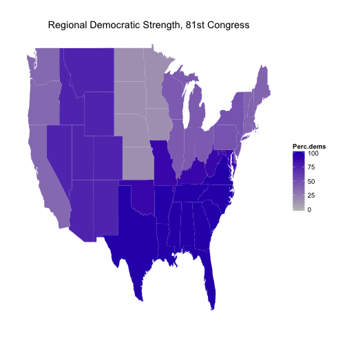

### Regional Democratic Strength

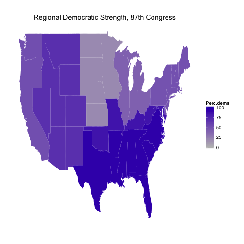

### Regional Democratic Strength

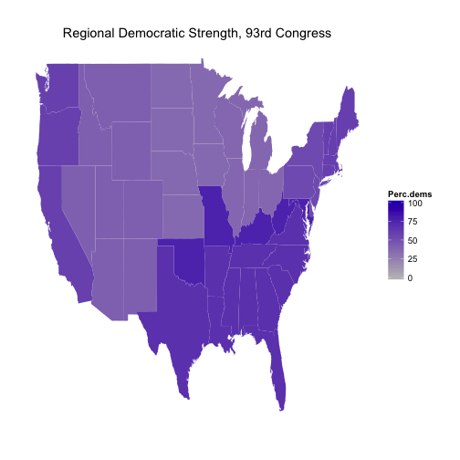

### Regional Democratic Strength

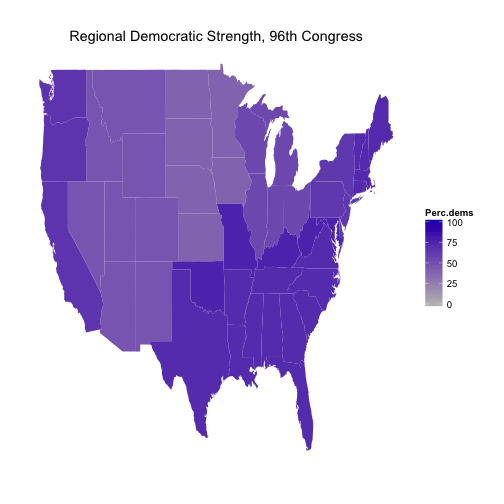

### Regional Democratic Strength

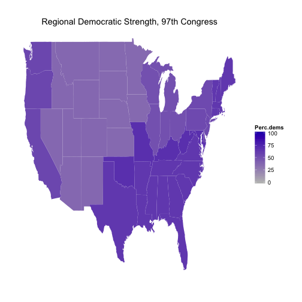

### Regional Democratic Strength

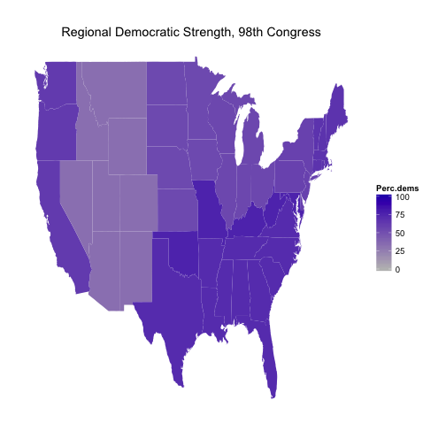

### Regional Democratic Strength

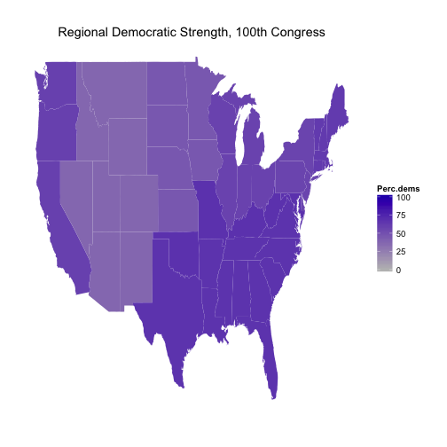

### Regional Democratic Strength

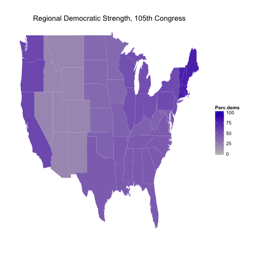

### Regional Democratic Strength

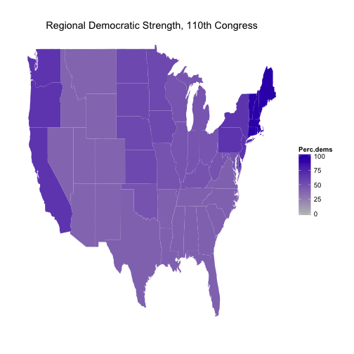

### Regional Democratic Strength

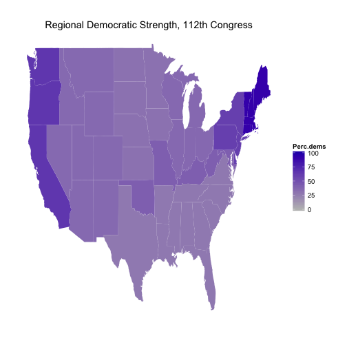

### Regional Democratic Strength

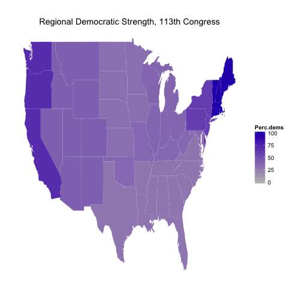

### Regional Democratic Strength

- Moves from Southern states, to Midwest and Mountain States
- End up with concentrations on the coasts, and very little strength in the middle

### Congressional Diversity

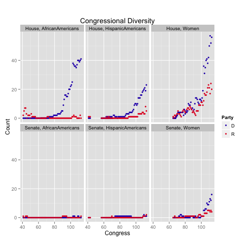

### Congressional Diversity

- Democrats tend to be more diverse than Republicans
- House more diverse than senate
- Focusing on women, the number of women in the the house is about the same for both parties, then the number of Democrats shoots up in the 103rd congress (1993-1994)

### Politics of Congress

Next, I look at political alignments and ideologies in Congress.

- Conservative/liberal ideology scores
- Party unity voting and polarization: A party unity vote is a vote in which a majority of Democrats opposed a majority of Republicans
- Presidential party solidarity and polarization

### Political Ideology of Congress

Quantified on a scale of (-1,1). A positive score denotes a conservative ideology, while a negative score denotes a liberal one. Further from zero is more extreme. See [Poole-Rosenthal Scores](http://www.voteview.com/about.asp) for more info.

[figure not shown]

### Quiz Time!

In which year was the House of Representatives the most ideologically **liberal** with a score of -0.126?

- **1975**, at the start of the 94th Congress
- Right after 1974 midterm elections, Nixon (Republican) president

In which year was the House of Representatives the most ideologically **conservative** with a score of 0.193?

- **2011**, at the start of the 112th Congress
- Right after the 2010 midterm elections, Obama (Democrat) president

### Political Ideology of Congress, cont.

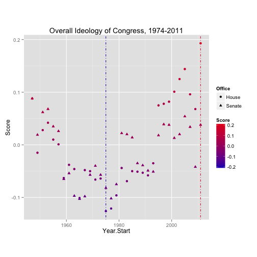

### Political Ideology of Congress, cont.

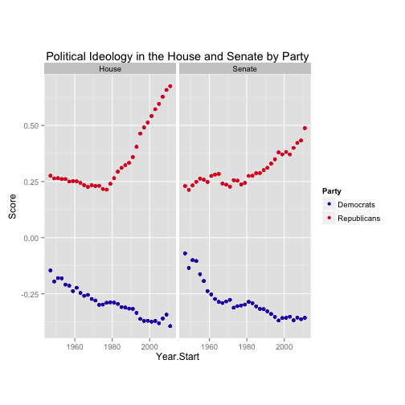

### Political Ideology of Congress, cont.

I was really intrigued by the pattern in House Republican scores, so I fit a change point model to see exactly where the increasing conservative trend started.

```r
library(segmented)
model<-segmented(lm(Score~Year.Start,data = rep.score.house),seg.Z =~Year.Start, psi = 1975)
```

Fitted Model:

- Score = 3.94 - 0.0019 * Year + 0.016 * (Year-1978)

### Political Ideology of Congress, cont.

The p-value for the change point is less than 2.2e-16. So, something significant happened in 1978 that started a trend that has changed political ideology of the Republican party in the U.S. drastically.

```r
pval<-davies.test(lm(Score~Year.Start,data = rep.score.house),~Year.Start,k = nrow(rep.score.house),alternative = 'two.sided')$p.value
pval
```

```
[1] 0
```

### Political Ideology of Congress, cont.

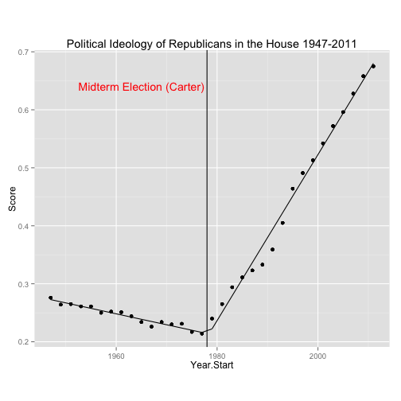

### Polarization of Congress

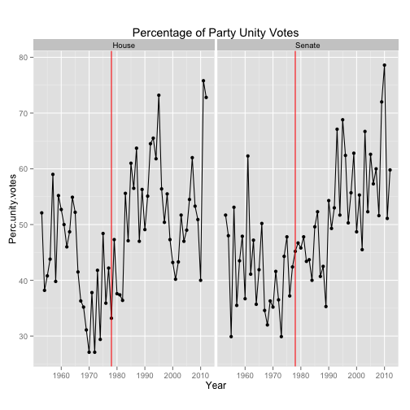

### Polarization of Congress, cont.

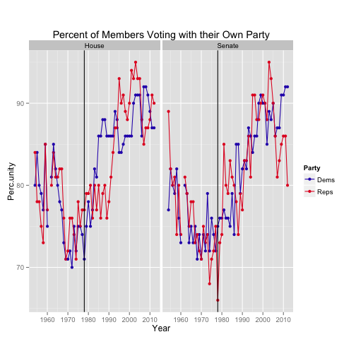

### Polarization of Congress, cont.

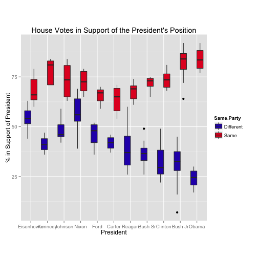

### Polarization of Congress, cont.

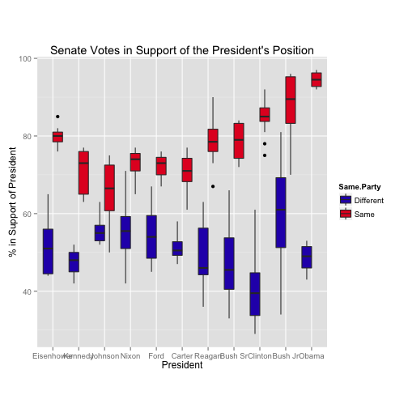

### Polarization of Congress, cont.

- Congress has become extremely polarized
- The start of this increasing polarization seems to be the midterm election of 1978
- This trend has continued for the last 30+ years, and shows no signs of stopping.